# The effect of digoxin on mortality and morbidity in patients with heart failure: a case of reproducible research

Giacomo Bianchi

2017-12-30

# Philosophy

> Statistics: the only science that enables different experts using the same figures to draw different conclusion **Evan Esar**

> The only statistics you can trust are those you falsified yourself. **Winston Churchill**

# Introduction and aim of the analysis

The aim of this analysis is to reproduce the landmark paper published by **The Digitalis Investigation Group** in 1997 in the *New England Journal of Medicine*<sup>1</sup>. The original dataset has been released for teaching purpose by the [National Heart Lung and Blood Institute](https://www.nhlbi.nih.gov/).

# Perform an Exploratory Data Analysis

## Read the dataset

The work of the data scientist or researcher begins with the exploration of the actual file that contains the data, its storage format and the way to read it. The file is in my directory `/data` and i can access it using the command line interface:

```bash
cd data
cat dig.csv | head -n 2
```

```
## ID,TRTMT,AGE,RACE,SEX,EJF_PER,EJFMETH,CHESTX,BMI,KLEVEL,CREAT,DIGDOSER,CHFDUR,RALES,ELEVJVP,PEDEMA,RESTDYS,EXERTDYS,ACTLIMIT,S3,PULCONG,NSYM,HEARTRTE,DIABP,SYSBP,FUNCTCLS,CHFETIOL,PREVMI,ANGINA,DIABETES,HYPERTEN,DIGUSE,DIURETK,DIURET,KSUPP,ACEINHIB,NITRATES,HYDRAL,VASOD,DIGDOSE,CVD,CVDDAYS,WHF,WH…
## 1,0,66,1,1,40,2,0.5,20.073,,1.261,0.25,96,0,0,0,0,1,1,0,2,3,96,80,126,1,1,0,1,1,0,1,0,1,1,1,0,1,0,0.25,1,1049,1,1379,0,1438,0,1438,0,1438,0,1438,0,1438,0,1438,0,1438,1,1049,0,1438,1,533,1,533,6,0,1438,,1,1379
```

The data are stored as “comma-separated-values” where the actual separator is, in fact, the “comma”. It’s a “tidy” dataset, where each row represent an patient and each column a variable. Now it can be read and stored using the appropriate function from the “tidyverse” package `read_csv()`.

```r
dig <- read_csv(file = "data/dig.csv",
                col_types = list(SEX = col_factor(levels = c("1", "2")),
                                 RACE = col_factor(levels = c("1", "2"))
                                 ))
```

## Dataset structure

Now is time to explore the structure of the dataframe with the appropriate functions.

```r
glimpse(dig)
```

```
## Observations: 6,800
## Variables: 72
## $ ID       <int> 1, 2, 3, 4, 5, 6, 7, 8, 9, 10, 11, 12, 13, 14, 15, 16...
## $ TRTMT    <int> 0, 0, 0, 1, 0, 0, 1, 1, 0, 1, 1, 1, 0, 0, 0, 0, 1, 0,...
## $ AGE      <int> 66, 77, 72, 57, 74, 69, 64, 60, 74, 64, 61, 56, 66, 4...
## $ RACE     <fct> 1, 1, 1, 1, 1, 2, 1, 2, 2, 1, 1, 1, 1, 1, 1, 1, 2, 1,...
## $ SEX      <fct> 1, 1, 2, 1, 1, 2, 2, 1, 1, 2, 2, 1, 2, 1, 1, 1, 1, 1,...
## $ EJF_PER  <int> 40, 12, 36, 31, 15, 45, 30, 39, 33, 24, 44, 23, 42, 3...
## $ EJFMETH  <int> 2, 1, 1, 1, 1, 1, 1, 1, 3, 1, 3, 1, 1, 1, 1, 3, 3, 1,...
## $ CHESTX   <dbl> 0.50, 0.56, 0.68, 0.48, 0.53, 0.70, 0.52, 0.40, 0.49,...
## $ BMI      <dbl> 20.073, 20.701, 25.530, 25.794, 25.654, 27.770, 31.69...
## $ KLEVEL   <dbl> NA, 3.1, 5.1, NA, 4.0, 4.3, 4.3, 5.1, 4.7, 4.0, 3.8, ...
## $ CREAT    <dbl> 1.261, 1.500, 1.239, 2.250, 1.466, 1.200, 1.300, 1.00...
## $ DIGDOSER <dbl> 0.250, 0.250, 0.250, 0.250, 0.375, 0.250, 0.250, 0.25...
## $ CHFDUR   <int> 96, 2, 12, 24, 288, 84, 31, 6, 12, 33, 3, 105, 1, 36,...
```

[output cut: 59 more lines]

The DIG trial was designed as a randomized, double-blind, multicenter trial with more than 300 centers.

First we can explore the distribution of data in some common variables.

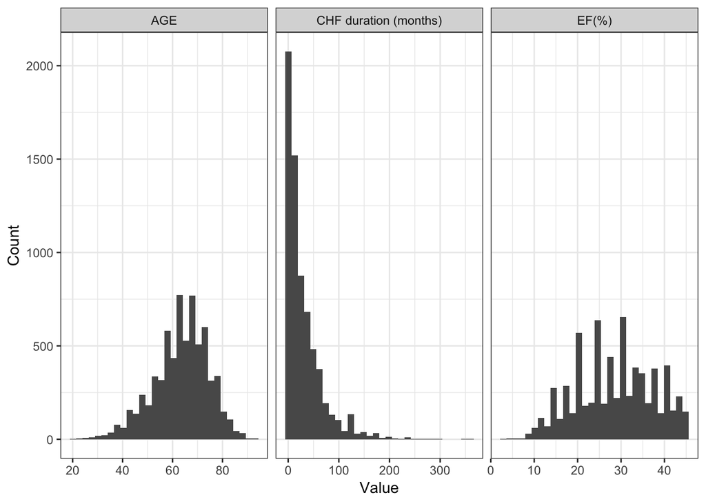

```r
#histograms by groups
histgg <- function(df, x, grp){
    x <- enquo(x) # the data
    grp <- enquo(grp) #the actual group
    ggplot(aes(!!x), data = df) +
        geom_histogram() +
        labs(x = "Value", y = "Count") +
        facet_grid(cols = vars(!!grp), scales = "free") +
        theme_bw()
}

expl <- dig %>% select(AGE, EJF_PER, CHFDUR) %>%
                mutate(ID = 1:nrow(dig)) %>%
                rename(`EF(%)` = EJF_PER, `CHF duration (months)` = CHFDUR) %>%
                gather(key = Variable, value = Measure, -ID)


histgg(df = expl, x = Measure, grp = Variable)
```

We can replicate the previous part using a different tools in R language.

The first is to calculate mean, sd and summarise for each group; another tool is to use a function of the `apply` family, i.e. `tapply()`; we can use tools from `tidyverse` such as `groupby()` and `summarize()`; finally a specific package `compareGroups()` that produces an output very close to publish-ready format we are use to in biomedical journals.

```r
#digoxin mean and sd
mean(dig$AGE[dig$TRTMT == 1], na.rm = TRUE)
```

```
## [1] 63.4189
```

```r
sd(dig$AGE[dig$TRTMT == 1], na.rm = TRUE)
```

```
## [1] 11.0244
```

```r
#placebo mean and sd
mean(dig$AGE[dig$TRTMT == 0], na.rm = TRUE)
```

```
## [1] 63.54746
```

```r
sd(dig$AGE[dig$TRTMT == 0], na.rm = TRUE)
```

```
## [1] 10.8136
```

```r
tapply(dig$AGE, dig$TRTMT, function(x) c(mean(x), sd(x)))
```

```
## $`0`
## [1] 63.54746 10.81360
##
## $`1`
## [1] 63.4189 11.0244
```

```r
dig %>%
    select(AGE, TRTMT) %>%
    mutate(TRTMT = factor(TRTMT)) %>%
    mutate(TRTMT = fct_recode(TRTMT, digoxin = "1", placebo = "0")) %>%
    group_by(TRTMT) %>%
    summarise(mean = mean(AGE), sd = sd(AGE))
```

```
## # A tibble: 2 x 3
##   TRTMT    mean    sd
##   <fct>   <dbl> <dbl>
## 1 placebo  63.5  10.8
## 2 digoxin  63.4  11.0
```

```r
summ_stat <- dig %>%
                select(AGE, EJF_PER, CHFDUR, TRTMT)
summ_stat_com <- compareGroups(TRTMT~AGE+EJF_PER+CHFDUR, data = summ_stat)
compareGroups::createTable(summ_stat_com)
```

```
##
## --------Summary descriptives table by 'TRTMT'---------
##
## _________________________________________
##              0           1      p.overall
##           N=3403      N=3397
## ¯¯¯¯¯¯¯¯¯¯¯¯¯¯¯¯¯¯¯¯¯¯¯¯¯¯¯¯¯¯¯¯¯¯¯¯¯¯¯¯¯
## AGE     63.5 (10.8) 63.4 (11.0)   0.627
## EJF_PER 28.4 (8.85) 28.6 (8.85)   0.380
## CHFDUR  29.8 (36.5) 30.5 (37.2)   0.422
## ¯¯¯¯¯¯¯¯¯¯¯¯¯¯¯¯¯¯¯¯¯¯¯¯¯¯¯¯¯¯¯¯¯¯¯¯¯¯¯¯¯
```

```r
mean_sd <- function(x, r)  {
    x <- as.numeric(x)
    r <- as.numeric(r) #insert the number for rounding
    m <- round(mean(x, na.rm = T),r) #calculate the mean
    s <- round(sd(x, na.rm = T),r) #calculate the SD
    result <- paste(m, s, sep="±") #create a character vector to be printed
    return(result) #print the string
}

#use tapply to
tapply(dig$AGE, dig$TRTMT, function(x) mean_sd(x, r = 2))
```

```
##             0             1
## "63.55±10.81" "63.42±11.02"
```

```r
tapply(dig$EJF_PER, dig$TRTMT, function(x) mean_sd(x, r = 2))
```

```
##            0            1
## "28.45±8.85" "28.63±8.85"
```

```r
tapply(dig$CHFDUR, dig$TRTMT, function(x) median(x, na.rm = TRUE))
```

```
##  0  1
## 16 17
```

Some are pretty, some others are pretty ugly as output. Anyway they confirm the reproducibility of the data written in the paper.

In the second part of Table 1 are listed all the categorical variables and expressed as percentage of patients. To reproduce it, we need to modify the existing variables and levels.

In this case, the Tidyverse function makes the life really easy.

```r
dig_cat <- dig %>%
                select(SEX, RACE, AGE, EJFMETH, CHESTX, FUNCTCLS, NSYM, PREVMI, ANGINA,
                       DIABETES, HYPERTEN, DIGUSE, CHFETIOL, DIURET, DIURETK, ACEINHIB,
                       NITRATES, HYDRAL, VASOD, DIGDOSER)

dig_cat <- dig_cat %>%
                mutate(SEX = fct_recode(SEX,
                                        "Male" = "1", "Female" = "2"))
```

# Bibliography

1. Group DI. The effect of digoxin on mortality and morbidity in patients with heart failure. *New England Journal of Medicine* [Internet]. 1997;336:525–533. Available from: http://dx.doi.org/10.1056/NEJM199702203360801